# Imprinted Regions - Exploration through DMR plots

## 4.2 hPGCLCs vs hEGCLCs_p10

### 4.2.1 Get DMRs hPGCLCs vs hEGCLCs

```r
comparison <- "hEGCLCs_p10vshPGCLCs"
DMRs <- DMRs_annotated[[comparison]]
```

### 4.2.2 Exploration of imprinted genes within hPGCLCs vs hEGCLCs_p10 DMRs

```r
ImprintedGenes <- ImprintedRegions_GRanges$`Gene locus`
```

```r
PresentGenes <- vector()
AbsentGenes <- vector()
for(gene_index in ImprintedGenes){
  if (any(DMRs$hgnc_symbol %in% gene_index)) {
    PresentGenes <- c(PresentGenes, gene_index)
    plotDMRs(bsseq_obj, regions=DMRs[DMRs$hgnc_symbol %in% gene_index,], testCovariate=3, annoTrack=annoTrack, qval = FALSE, stat = FALSE, extend = 5000, main = paste0(gene_index," - ", DMRs[DMRs$hgnc_symbol %in% gene_index,]$ChipSeekerAnn), verbose = FALSE, horizLegend = TRUE, col = c(rep(cellTypes_colors[1], each = 5), rep(cellTypes_colors[2], each = 4),rep(cellTypes_colors[3:5], each = 3)))
  } else{
    AbsentGenes <- c(AbsentGenes, gene_index)
    next}
}
```

These genes were found: These genes were not found: PPIEL, DIRAS3_Ex2, DIRAS3, GPR1_AS, ZDBF2, MCCC1, NAP1L5, PDE4D, FAM50B, LIN28B, AIM1, PLAGL1_HYMAI, IGF2R_SLC22A2_3, WDR27, GRB10, SGCE_PEG10, MEST, AGBL3, HTR5A, CXORF56_pseudogene_ERLIN2, ZFAT, TRAPPC9, GLIS3, DCAF10, INPP5F, FAM196A_DOCK1, H19, IGF2_DMR2, IGF2_DMR0, KvDMR1, ZC3H12C, N4BP2L1, RB1, IG_DMR, MEG3, MEG8, MKRN3_MIR4508, MAGEL2, NDN, SNRPN_intragenic_CpG32, SNRPN_intragenic_CpG29, SNRPN_intragenic_CpG30, SNRPN_intragenic_CpG40, SNRPN, SNRPN, SNRPN, SNURF, RGMA, IGF1R, ZNF597, ZNF597_NAA60, FAM20A, ZNF396, DNMT1, ZNF331, ZNF331, MIR512_1_cluster, PEG3, MCTS2P_HM13, BLCAP_NNAT, L3MBTL, GNAS, NESP_AS_GNAS_AS1, GNAS_XL, GNAS_Ex1A, WRB, NHP2L1, KCNQ1_KCNQ1OT1, KCNQ1_KCNQ1OT1, MEST_MESTIT1, ZIM2_PEG3_MIMT1, DLK1_DIO3

### 4.2.3 Exploration of irie et al., 2023 relevant genes

```r
SelectedGenes <- c("CDH5", "DMRT1", "PIWIL2", "DAZL")
```

```r
PresentGenes <- vector()
AbsentGenes <- vector()
for(gene_index in SelectedGenes){
  if (any(DMRs$hgnc_symbol %in% gene_index)) {
    PresentGenes <- c(PresentGenes, gene_index)
    plotDMRs(bsseq_obj, regions=DMRs[DMRs$hgnc_symbol %in% gene_index,], testCovariate=3, annoTrack=annoTrack, qval = FALSE, stat = FALSE, extend = 5000, main = paste0(gene_index," - ", DMRs[DMRs$hgnc_symbol %in% gene_index,]$ChipSeekerAnn), verbose = FALSE, horizLegend = TRUE, col = c(rep(cellTypes_colors[1], each = 5), rep(cellTypes_colors[2], each = 4),rep(cellTypes_colors[3:5], each = 3)))
  } else{
    AbsentGenes <- c(AbsentGenes, gene_index)
    next}
}
```

These genes were found: These genes were not found: CDH5, DMRT1, PIWIL2, DAZL

## 4.3 hEGCLCs_p10 vs hEGCLCs_p5

```r
comparison <- "hEGCLCs_p10vshEGCLCs_p5"
DMRs <- DMRs_annotated[[comparison]]
```

```r
ImprintedGenes <- ImprintedRegions_GRanges$`Gene locus`
```

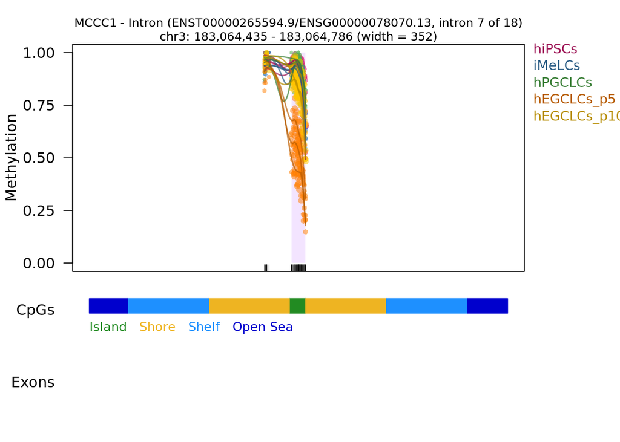

```r
PresentGenes <- vector()
AbsentGenes <- vector()
for(gene_index in ImprintedGenes){
  if (any(DMRs$hgnc_symbol %in% gene_index)) {
    PresentGenes <- c(PresentGenes, gene_index)
    plotDMRs(bsseq_obj, regions=DMRs[DMRs$hgnc_symbol %in% gene_index,], testCovariate=3, annoTrack=annoTrack, qval = FALSE, stat = FALSE, extend = 5000, main = paste0(gene_index," - ", DMRs[DMRs$hgnc_symbol %in% gene_index,]$ChipSeekerAnn), verbose = FALSE, horizLegend = TRUE, col = c(rep(cellTypes_colors[1], each = 5), rep(cellTypes_colors[2], each = 4),rep(cellTypes_colors[3:5], each = 3)))
  } else{
    AbsentGenes <- c(AbsentGenes, gene_index)
    next}
}
```

These genes were found: MCCC1 These genes were not found: PPIEL, DIRAS3_Ex2, DIRAS3, GPR1_AS, ZDBF2, NAP1L5, PDE4D, FAM50B, LIN28B, AIM1, PLAGL1_HYMAI, IGF2R_SLC22A2_3, WDR27, GRB10, SGCE_PEG10, MEST, AGBL3, HTR5A, CXORF56_pseudogene_ERLIN2, ZFAT, TRAPPC9, GLIS3, DCAF10, INPP5F, FAM196A_DOCK1, H19, IGF2_DMR2, IGF2_DMR0, KvDMR1, ZC3H12C, N4BP2L1, RB1, IG_DMR, MEG3, MEG8, MKRN3_MIR4508, MAGEL2, NDN, SNRPN_intragenic_CpG32, SNRPN_intragenic_CpG29, SNRPN_intragenic_CpG30, SNRPN_intragenic_CpG40, SNRPN, SNRPN, SNRPN, SNURF, RGMA, IGF1R, ZNF597, ZNF597_NAA60, FAM20A, ZNF396, DNMT1, ZNF331, ZNF331, MIR512_1_cluster, PEG3, MCTS2P_HM13, BLCAP_NNAT, L3MBTL, GNAS, NESP_AS_GNAS_AS1, GNAS_XL, GNAS_Ex1A, WRB, NHP2L1, KCNQ1_KCNQ1OT1, KCNQ1_KCNQ1OT1, MEST_MESTIT1, ZIM2_PEG3_MIMT1, DLK1_DIO3

### 4.3.3 Exploration of irie et al., 2023 relevant genes

```r
SelectedGenes <- c("CDH5", "DMRT1", "PIWIL2", "DAZL")
```

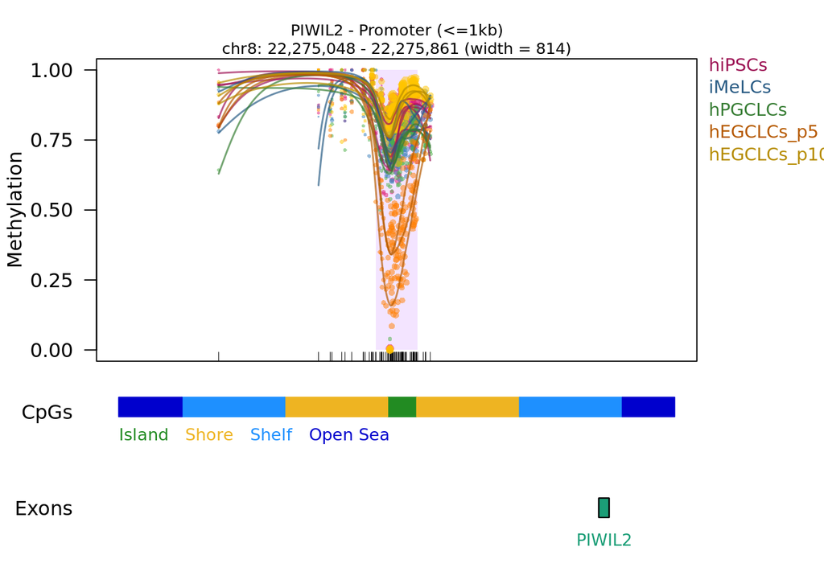

```r
PresentGenes <- vector()
AbsentGenes <- vector()
for(gene_index in SelectedGenes){
  if (any(DMRs$hgnc_symbol %in% gene_index)) {
    PresentGenes <- c(PresentGenes, gene_index)
    plotDMRs(bsseq_obj, regions=DMRs[DMRs$hgnc_symbol %in% gene_index,], testCovariate=3, annoTrack=annoTrack, qval = FALSE, stat = FALSE, extend = 5000, main = paste0(gene_index," - ", DMRs[DMRs$hgnc_symbol %in% gene_index,]$ChipSeekerAnn), verbose = FALSE, horizLegend = TRUE, col = c(rep(cellTypes_colors[1], each = 5), rep(cellTypes_colors[2], each = 4),rep(cellTypes_colors[3:5], each = 3)))
  } else{
    AbsentGenes <- c(AbsentGenes, gene_index)
    next}
}
```

These genes were found: PIWIL2 These genes were not found: CDH5, DMRT1, DAZL

## 4.4 iMeLCs vs hEGCLCs_p10

### 4.4.1 Get DMRs iMeLCs vs hEGCLCs_p10

```r
comparison <- "hEGCLCs_p10vsiMeLCs"
DMRs <- DMRs_annotated[[comparison]]
```

### 4.4.2 Exploration of imprinted genes within iMeLCs vs hEGCLCs_p10 DMRs

```r
ImprintedGenes <- ImprintedRegions_GRanges$`Gene locus`
```

```r
PresentGenes <- vector()
AbsentGenes <- vector()
for(gene_index in ImprintedGenes){
  if (any(DMRs$hgnc_symbol %in% gene_index)) {
    PresentGenes <- c(PresentGenes, gene_index)
    plotDMRs(bsseq_obj, regions=DMRs[DMRs$hgnc_symbol %in% gene_index,], testCovariate=3, annoTrack=annoTrack, qval = FALSE, stat = FALSE, extend = 5000, main = paste0(gene_index," - ", DMRs[DMRs$hgnc_symbol %in% gene_index,]$ChipSeekerAnn), verbose = FALSE, horizLegend = TRUE, col = c(rep(cellTypes_colors[1], each = 5), rep(cellTypes_colors[2], each = 4),rep(cellTypes_colors[3:5], each = 3)))
  } else{
    AbsentGenes <- c(AbsentGenes, gene_index)
    next}
}
```

These genes were found: These genes were not found: PPIEL, DIRAS3_Ex2, DIRAS3, GPR1_AS, ZDBF2, MCCC1, NAP1L5, PDE4D, FAM50B, LIN28B, AIM1, PLAGL1_HYMAI, IGF2R_SLC22A2_3, WDR27, GRB10, SGCE_PEG10, MEST, AGBL3, HTR5A, CXORF56_pseudogene_ERLIN2, ZFAT, TRAPPC9, GLIS3, DCAF10, INPP5F, FAM196A_DOCK1, H19, IGF2_DMR2, IGF2_DMR0, KvDMR1, ZC3H12C, N4BP2L1, RB1, IG_DMR, MEG3, MEG8, MKRN3_MIR4508, MAGEL2, NDN, SNRPN_intragenic_CpG32, SNRPN_intragenic_CpG29, SNRPN_intragenic_CpG30, SNRPN_intragenic_CpG40, SNRPN, SNRPN, SNRPN, SNURF, RGMA, IGF1R, ZNF597, ZNF597_NAA60, FAM20A, ZNF396, DNMT1, ZNF331, ZNF331, MIR512_1_cluster, PEG3, MCTS2P_HM13, BLCAP_NNAT, L3MBTL, GNAS, NESP_AS_GNAS_AS1, GNAS_XL, GNAS_Ex1A, WRB, NHP2L1, KCNQ1_KCNQ1OT1, KCNQ1_KCNQ1OT1, MEST_MESTIT1, ZIM2_PEG3_MIMT1, DLK1_DIO3

### 4.4.3 Exploration of irie et al., 2023 relevant genes

```r
SelectedGenes <- c("CDH5", "DMRT1", "PIWIL2", "DAZL")
```

```r
PresentGenes <- vector()
AbsentGenes <- vector()
for(gene_index in SelectedGenes){
  if (any(DMRs$hgnc_symbol %in% gene_index)) {
    PresentGenes <- c(PresentGenes, gene_index)
    plotDMRs(bsseq_obj, regions=DMRs[DMRs$hgnc_symbol %in% gene_index,], testCovariate=3, annoTrack=annoTrack, qval = FALSE, stat = FALSE, extend = 5000, main = paste0(gene_index," - ", DMRs[DMRs$hgnc_symbol %in% gene_index,]$ChipSeekerAnn), verbose = FALSE, horizLegend = TRUE, col = c(rep(cellTypes_colors[1], each = 5), rep(cellTypes_colors[2], each = 4),rep(cellTypes_colors[3:5], each = 3)))
  } else{
    AbsentGenes <- c(AbsentGenes, gene_index)
    next}
}
```

These genes were found: These genes were not found: CDH5, DMRT1, PIWIL2, DAZL

# 5. Imprinted regions in the bsseq object

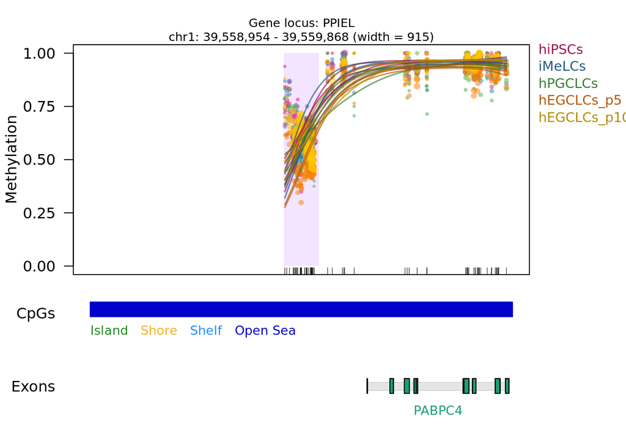

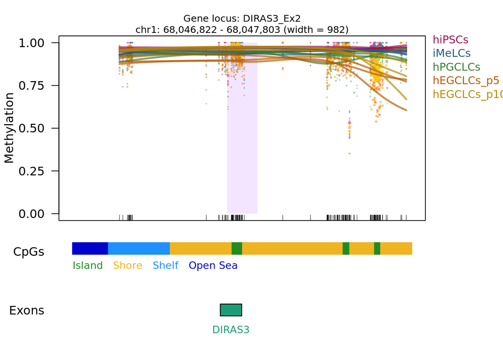

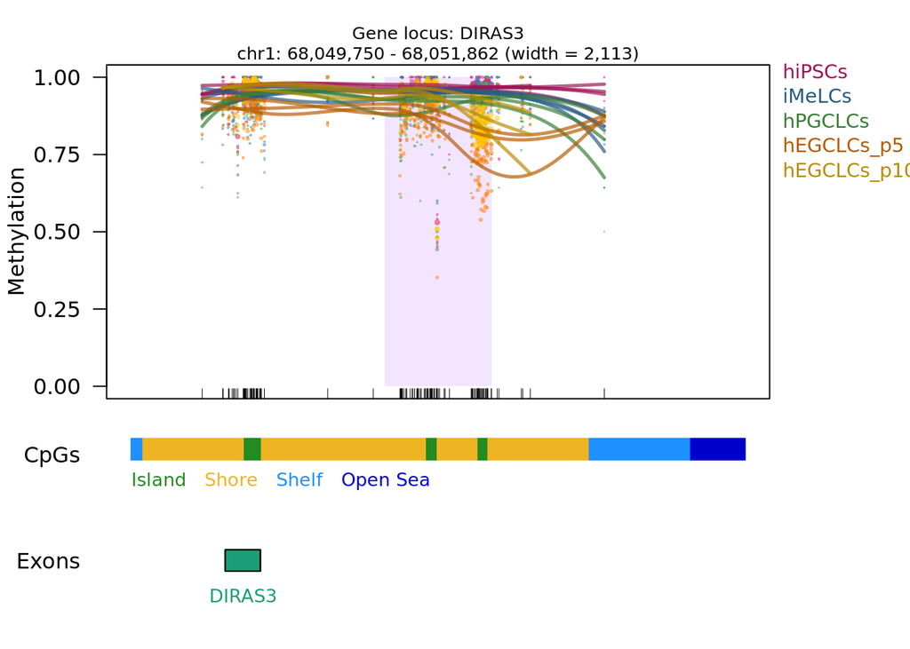

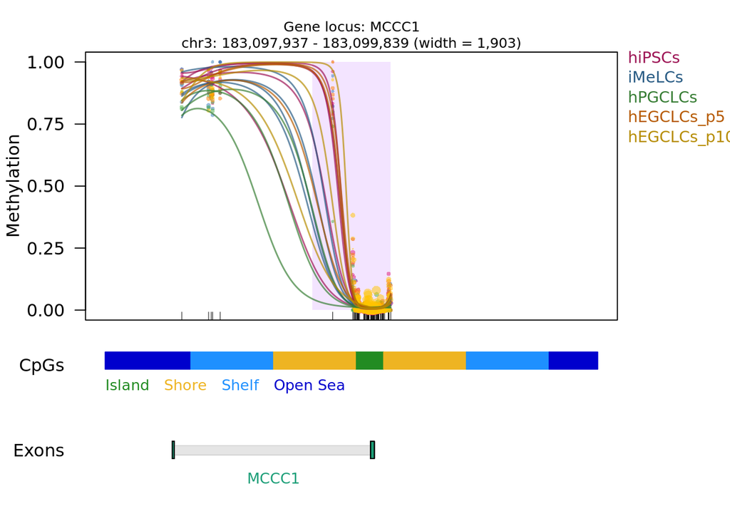

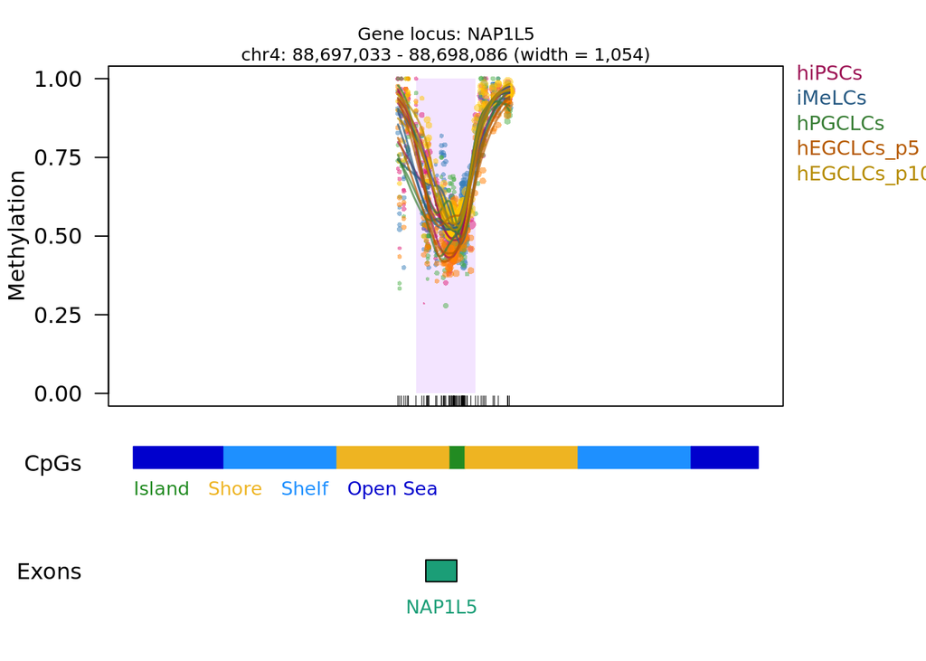

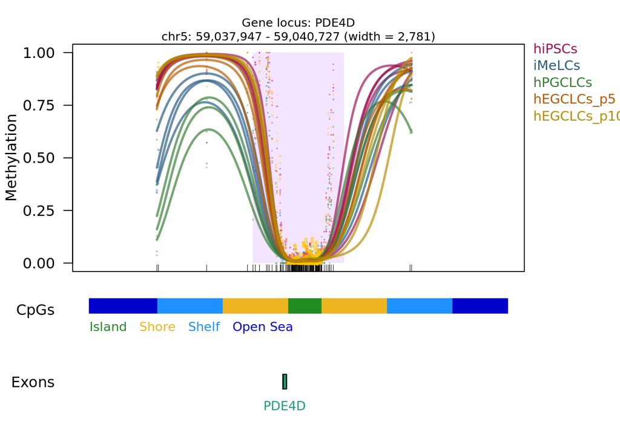

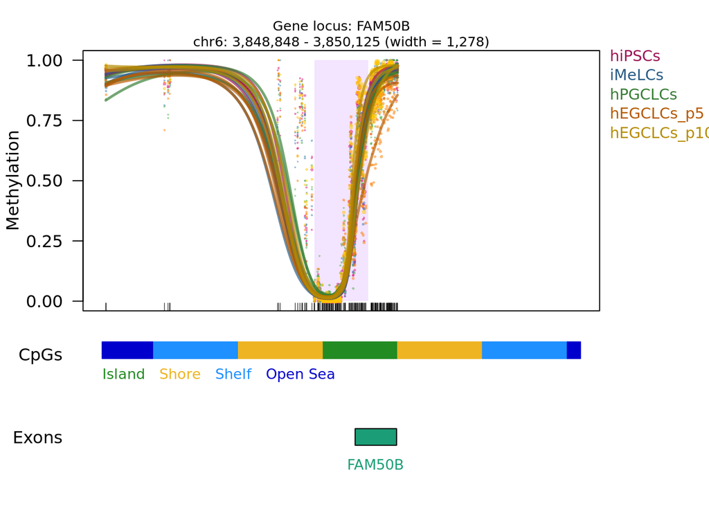

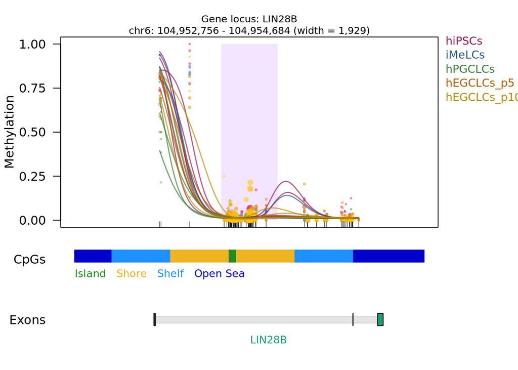

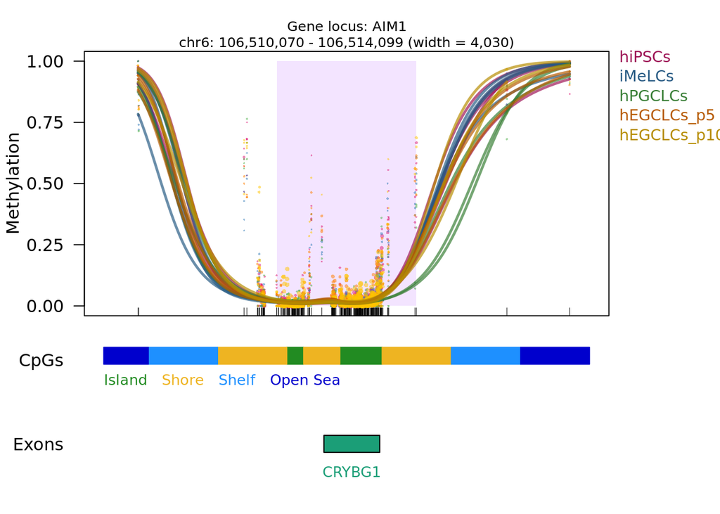

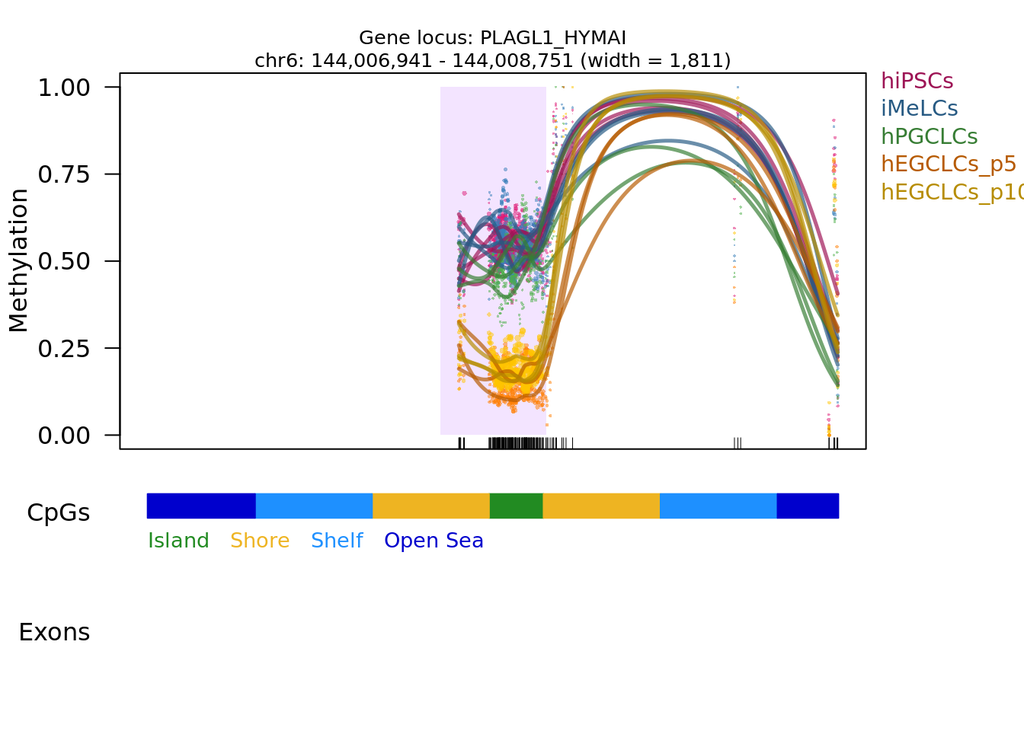

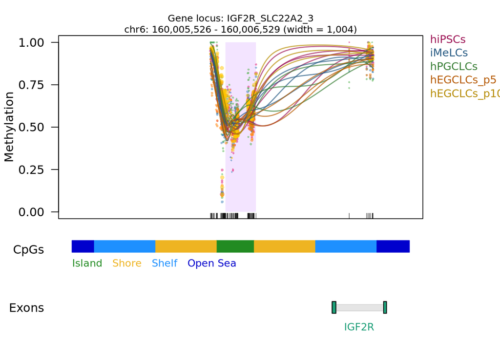

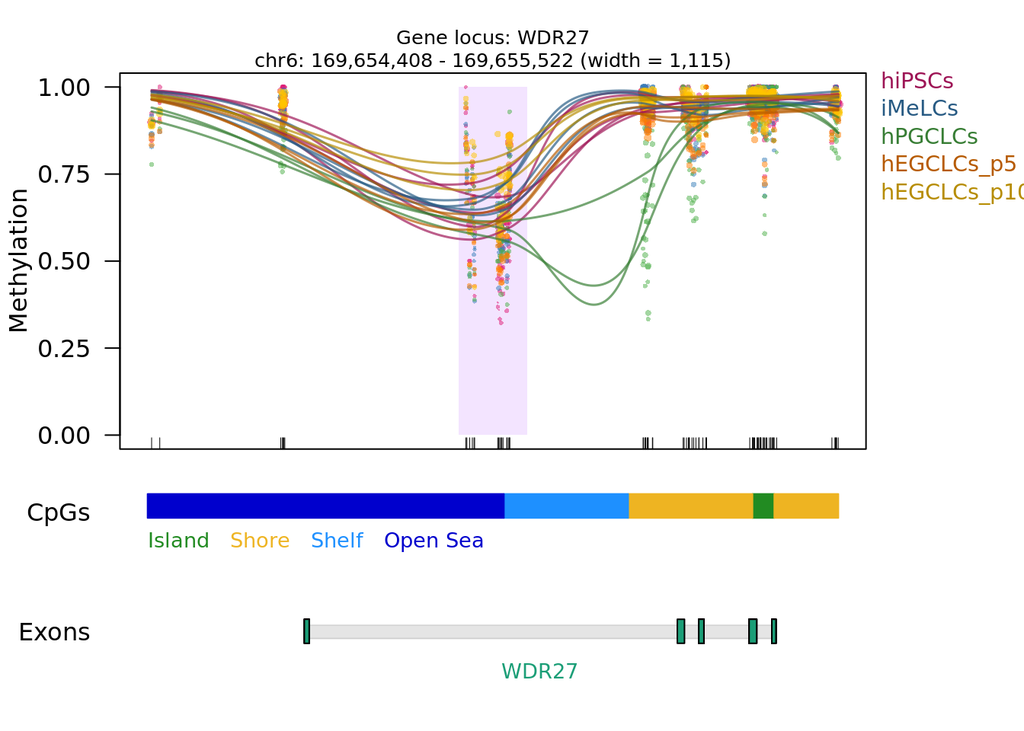

[52 more figures not shown]

```r
for (region in 1:length(ImprintedRegions_GRanges)) {
    tryCatch({
      plotDMRs(bsseq_obj, regions=ImprintedRegions_GRanges[region,], testCovariate=3, annoTrack=annoTrack, main = paste0("Gene locus: ", ImprintedRegions_GRanges[region,]$`Gene locus`), qval = FALSE, stat = FALSE, extend = 5000, verbose = FALSE, horizLegend = TRUE, col = c(rep(cellTypes_colors[1], each = 5), rep(cellTypes_colors[2], each = 4),rep(cellTypes_colors[3:5], each = 3)))
      }, error=function(e){})
}
```

# 6. Date and Session Info

```r
date()
```

```
## [1] "Tue Aug 19 15:23:08 2025"
```